# Hands-on Exercise 11

“In this hands-on exercise, I will learn to how to model geographical accessibility by using R’s geospatial analysis packages”

Niharika Avula https://example.com/norajones  
2021-11-01

# 1. Overview

By the end to this hands-on exercise, the following will be covered:

- to import GIS polygon data into R and save them as simple feature data frame by using appropriate functions of sf package of R
- to import aspatial data into R and save them as simple feature data frame by using appropriate functions of sf package of R
- to computer accessibility measure by using Hansen’s potential model and Spatial Accessibility Measure (SAM)
- to visualise the accessibility measures by using tmap and ggplot2 packages

# 2. Getting Started

## 2.1 The data

Four data sets will be used in this hands-on exercise, they are:

- **MP14_SUBZONE_NO_SEA_PL:** URA Master Plan 2014 subzone boundary GIS data. This data set is downloaded from data.gov.sg.
- **hexagons:** A 250m radius hexagons GIS data. This data set was created by using st_make_grid() of sf package. It is in ESRI shapefile format.
- **ELDERCARE:** GIS data showing location of eldercare service. This data is downloaded from data.gov.sg. There are two versions. One in ESRI shapefile format. The other one in Google kml file format. For the purpose of this hands-on exercise, ESRI shapefile format is provided.
- **OD_Matrix:** a distance matrix in csv format which has six fields:
  - **origin_id:** the unique id values of the origin (i.e. fid of hexagon data set.)
  - **destination_id:** the unique id values of the destination (i.e. fid of ELDERCARE data set.)
  - **entry_cost:** the perpendicular distance between the origins and the nearest road)
  - **network_cost:** the actual network distance from the origin and destination
  - **exit_cost:** the perpendicular distance between the destination and the nearest road)
  - **total_cost:** the summation of entry_cost, network_cost and exit_cost

All the values of the cost related fields are in metres.

## 2.2 Installing and loading R packages

The R packages needed for this exercise are as follows: * **sf:** Spatial data handling * **spatialAcc:** Modelling geographical accessibility * **tidyverse**: Attribute data handling * **tmap:**: Thematic mapping * **ggplot2:** Statistical graphic * **ggstatsplot:** Statistical analysis

The code chunk below installs and launches these R packages into RStudio environment.

```r
packages = c('tmap', 'SpatialAcc',
             'sf', 'ggstatsplot', 'reshape2',
             'tidyverse')

for(p in packages){
  if(!require(p, character.only = T)){
    install.packages(p)
  }
  library(p, character.only = T)
}
```

# 3. Geospatial Data Handling and Wrangling

## 3.1 Importing geospatial data

The code chunk below is used to import these three data sets shapefile by using st_read() of sf packages: * MP14_SUBZONE_NO_SEA_PL * hexagons * ELDERCARE

```r
mpsz <- st_read(dsn = "data/geospatial", layer = "MP14_SUBZONE_NO_SEA_PL")
hexagons <- st_read(dsn = "data/geospatial", layer = "hexagons")
eldercare <- st_read(dsn = "data/geospatial", layer = "ELDERCARE")
```

## 3.2 Updating CRS information

The code chunk below updates the newly imported mpsz with the correct ESPG code (i.e. 3414)

```r
mpsz <- st_transform(mpsz, 3414)
eldercare <- st_transform(eldercare, 3414)
hexagons <- st_transform(hexagons, 3414)
```

After transforming the projection metadata, you can verify the projection of the newly transformed mpsz by using st_crs() of sf package.

The code chunk below will be used to varify the newly transformed mpsz.

```r
st_crs(mpsz)
```

```
Coordinate Reference System:
  User input: EPSG:3414
  wkt:
PROJCRS["SVY21 / Singapore TM",
    BASEGEOGCRS["SVY21",
        DATUM["SVY21",
            ELLIPSOID["WGS 84",6378137,298.257223563,
                LENGTHUNIT["metre",1]]],
        PRIMEM["Greenwich",0,
            ANGLEUNIT["degree",0.0174532925199433]],
        ID["EPSG",4757]],
    CONVERSION["Singapore Transverse Mercator",
        METHOD["Transverse Mercator",
            ID["EPSG",9807]],
        PARAMETER["Latitude of natural origin",1.36666666666667,
            ANGLEUNIT["degree",0.0174532925199433],
            ID["EPSG",8801]],
        PARAMETER["Longitude of natural origin",103.833333333333,
            ANGLEUNIT["degree",0.0174532925199433],
            ID["EPSG",8802]],
        PARAMETER["Scale factor at natural origin",1,
            SCALEUNIT["unity",1],
            ID["EPSG",8805]],
        PARAMETER["False easting",28001.642,
            LENGTHUNIT["metre",1],
            ID["EPSG",8806]],
        PARAMETER["False northing",38744.572,
            LENGTHUNIT["metre",1],
            ID["EPSG",8807]]],
    CS[Cartesian,2],
        AXIS["northing (N)",north,
            ORDER[1],
            LENGTHUNIT["metre",1]],
        AXIS["easting (E)",east,
            ORDER[2],
            LENGTHUNIT["metre",1]],
    USAGE[
        SCOPE["Cadastre, engineering survey, topographic mapping."],
        AREA["Singapore - onshore and offshore."],
        BBOX[1.13,103.59,1.47,104.07]],
    ID["EPSG",3414]]
```

## 3.3 Cleaning and updating attribute fields of the geospatial data

There are many redundant fields in the data tables of both eldercare and hexagons. The code chunks below will be used to exclude those redundant fields. At the same time, a new field called demand and a new field called capacity will be added into the data table of hexagons and eldercare sf data frame respectively. Both fields are derive using mutate() of dplyr package.

```r
eldercare <- eldercare %>%
  select(fid, ADDRESSPOS) %>%
  mutate(capacity = 100)
```

```r
hexagons <- hexagons %>%
  select(fid) %>%
  mutate(demand = 100)
```

Notice that for the purpose of this hands-on exercise, a constant value of 100 is used. In practice, actual demand of the hexagon and capacity of the eldercare centre should be used.

# 4. Apsaital Data Handling and Wrangling

## 4.1 Importing Distance Matrix

The code chunk below uses read_cvs() of readr package to import OD_Matrix.csv into RStudio. The imported object is a tibble data.frame called ODMatrix.

```r
ODMatrix <- read_csv("data/aspatial/OD_Matrix.csv", skip = 0)
```

## 4.2 Tidying distance matrix

**TRANSFORM MATRIX**

- *spread()* of **tidyr** package is used to transform the O-D matrix from a thin format into a fat format.

**Note:** We should use *pivot_wider()* instead of *spread()*

```r
distmat <- ODMatrix %>%
  select(origin_id, destination_id, total_cost) %>%
  spread(destination_id, total_cost)%>%
  select(c(-c('origin_id')))
```

**CONVERT FROM M TO KM**

- The distance is measured in metre because SVY21 projected coordinate system is used
- The code chunk below will be used to convert the unit f measurement from metre to kilometre using as.matrix() of Base R

```r
distmat_km<-as.matrix(distmat/1000)
```

# 5. Modelling and Visualising Accessibility using Hansen Method

## 5.1 Computing Hansen’s accessibility

- *ac()* of **SpatialAcc** package to compute Hansen’s accessibility
- *data.frame()* is used to save the output in a data frame called acc_Hansen

```r
acc_Hansen <- data.frame(ac(hexagons$demand, eldercare$capacity, distmat_km, d0 = 50, power = 2, family = "Hansen"))
```

The default field name is very messy, we will rename it to accHansen by using the code chunk below.

- colnames() of Base R to rename column names

```r
colnames(acc_Hansen) <- "accHansen"
```

Next, we will convert the data table into tibble format by using the code chunk below.

```r
acc_Hansen <- tbl_df(acc_Hansen)
```

Lastly, bind_cols() of dplyr will be used to join the acc_Hansen tibble data frame with the hexagons simple feature data frame. The output is called hexagon_Hansen.

```r
hexagon_Hansen <- bind_cols(hexagons, acc_Hansen)
```

Notice that hexagon_Hansen is a simple feature data frame and not a typical tibble data frame.

## 5.2 Visualising Hansen’s accessibility

**EXTRACTING MAP EXTEND**

Firstly, we will extract the extend of hexagons simple feature data frameby by using *st_bbox()* of **sf** package.

```r
mapex <- st_bbox(hexagons) #view extent
```

The code chunk below uses a collection of mapping fucntions of tmap package to create a high cartographic quality accessibility to eldercare centre in Singapore.

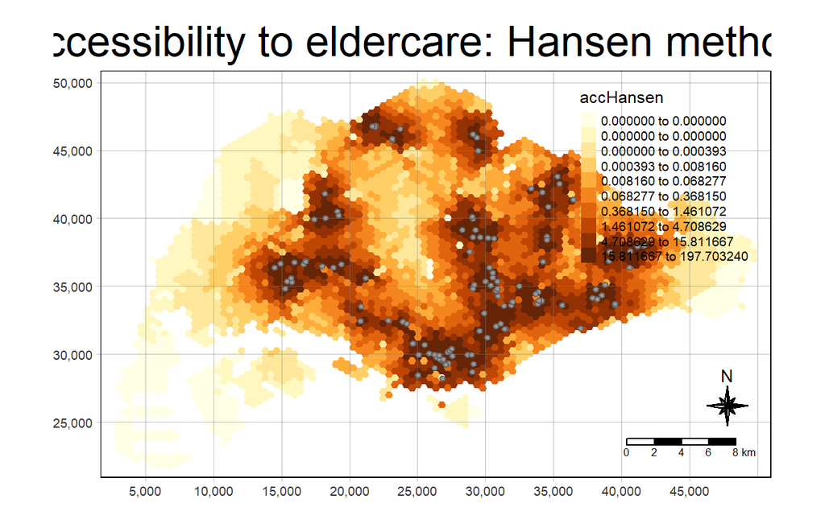

```r
tmap_mode("plot")
tm_shape(hexagon_Hansen,
         bbox = mapex) +
  tm_fill(col = "accHansen",
          n = 10,
          style = "quantile",
          border.col = "black",
          border.lwd = 1) +
tm_shape(eldercare) +
  tm_symbols(size = 0.1) +
  tm_layout(main.title = "Accessibility to eldercare: Hansen method",
            main.title.position = "center",
            main.title.size = 2,
            legend.outside = FALSE,
            legend.height = 0.45,
            legend.width = 3.0,
            legend.format = list(digits = 6),
            legend.position = c("right", "top"),
            frame = TRUE) +
  tm_compass(type="8star", size = 2) +
  tm_scale_bar(width = 0.15) +
  tm_grid(lwd = 0.1, alpha = 0.5)
```

# 5.3 Statistical graphic visualisation

In this section, we are going to compare the distribution of Hansen’s accessibility values by URA Planning Region.

Firstly, we need to add the planning region field into haxegon_Hansen simple feature data frame by using the code chunk below.

```r
hexagon_Hansen <- st_join(hexagon_Hansen, mpsz,
                          join = st_intersects)
```

Next, ggplot() will be used to plot the distribution by using boxplot graphical method.

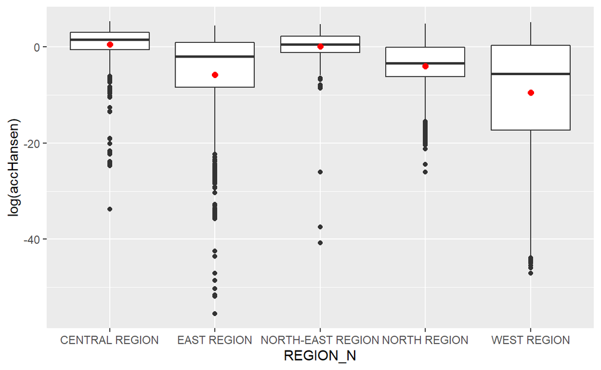

```r
ggplot(data=hexagon_Hansen,
       aes(y = log(accHansen),
           x= REGION_N)) +
  geom_boxplot() +
  geom_point(stat="summary",
             fun.y="mean",
             colour ="red",
             size=2)
```

# 6. Modelling and Visualising Accessibility using KD2SFCA Method

## 6.1 Computing KD2SFCA’s accessibility

```r
acc_KD2SFCA <- data.frame(ac(hexagons$demand,
                            eldercare$capacity,
                            distmat_km,
                            d0 = 50,
                            power = 2,
                            family = "KD2SFCA"))

colnames(acc_KD2SFCA) <- "accKD2SFCA"
acc_KD2SFCA <- tbl_df(acc_KD2SFCA)
hexagon_KD2SFCA <- bind_cols(hexagons, acc_KD2SFCA)
```

## 6.2 Visualising KD2SFCA’s accessibility

The code chunk below uses a collection of mapping fucntions of tmap package to create a high cartographic quality accessibility to eldercare centre in Singapore. Notice that mapex is reused for bbox argument.

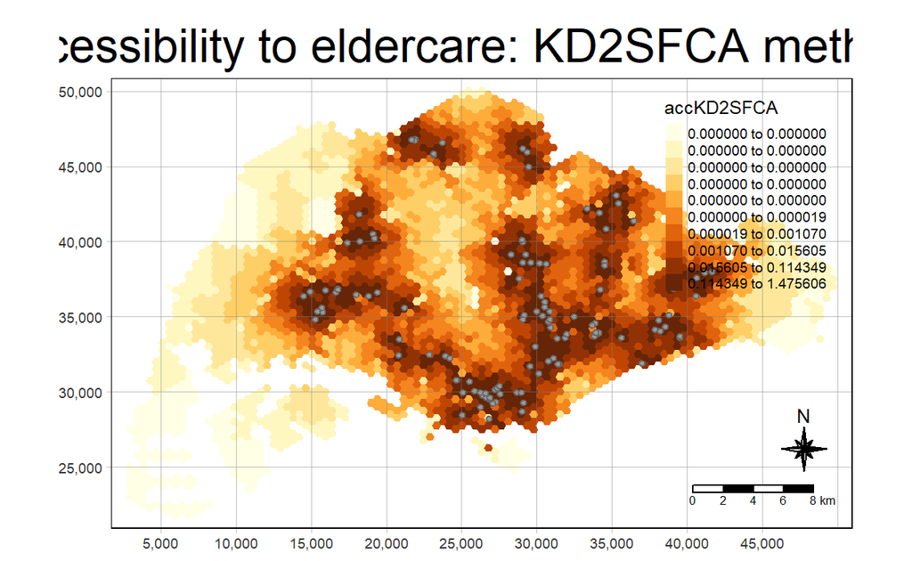

```r
tmap_mode("plot")
tm_shape(hexagon_KD2SFCA,
         bbox = mapex) +
  tm_fill(col = "accKD2SFCA",
          n = 10,
          style = "quantile",
          border.col = "black",
          border.lwd = 1) +
tm_shape(eldercare) +
  tm_symbols(size = 0.1) +
  tm_layout(main.title = "Accessibility to eldercare: KD2SFCA method",
            main.title.position = "center",
            main.title.size = 2,
            legend.outside = FALSE,
            legend.height = 0.45,
            legend.width = 3.0,
            legend.format = list(digits = 6),
            legend.position = c("right", "top"),
            frame = TRUE) +
  tm_compass(type="8star", size = 2) +
  tm_scale_bar(width = 0.15) +
  tm_grid(lwd = 0.1, alpha = 0.5)
```

## 6.3 Statistical graphic visualisation

Here, we will compare the distribution of KD2CFA accessibility values by URA Planning Region.

Firstly, we need to add the planning region field into hexagon_KD2SFCA simple feature data frame by using the code chunk below.

```r
hexagon_KD2SFCA <- st_join(hexagon_KD2SFCA, mpsz,
                          join = st_intersects)
```

Next, ggplot() will be used to plot the distribution by using boxplot graphical method.

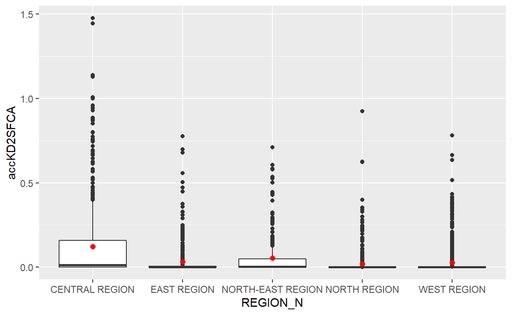

```r
ggplot(data=hexagon_KD2SFCA,
       aes(y = accKD2SFCA,
           x= REGION_N)) +
  geom_boxplot() +
  geom_point(stat="summary",
             fun.y="mean",
             colour ="red",
             size=2)
```

# 7. Modelling and Visualising Accessibility using Spatial Accessibility Measure (SAM) Method

## 7.1 Computing SAM accessibility

```r
acc_SAM <- data.frame(ac(hexagons$demand,
                         eldercare$capacity,
                         distmat_km,
                         d0 = 50,
                         power = 2,
                         family = "SAM"))

colnames(acc_SAM) <- "accSAM"
acc_SAM <- tbl_df(acc_SAM)
hexagon_SAM <- bind_cols(hexagons, acc_SAM)
```

## 7.2 Visualising SAM’s accessibility

The code chunk below uses a collection of mapping fucntions of tmap package to create a high cartographic quality accessibility to eldercare centre in Singapore. Notice that mapex is reused for bbox argument.

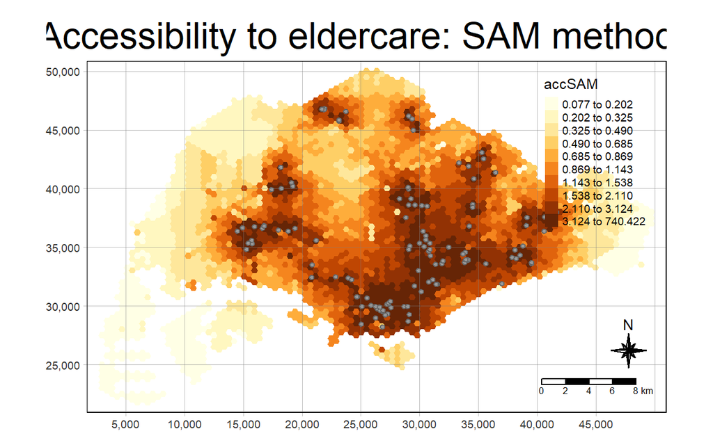

```r
tmap_mode("plot")
tm_shape(hexagon_SAM,
         bbox = mapex) +
  tm_fill(col = "accSAM",
          n = 10,
          style = "quantile",
          border.col = "black",
          border.lwd = 1) +
tm_shape(eldercare) +
  tm_symbols(size = 0.1) +
  tm_layout(main.title = "Accessibility to eldercare: SAM method",
            main.title.position = "center",
            main.title.size = 2,
            legend.outside = FALSE,
            legend.height = 0.45,
            legend.width = 3.0,
            legend.format = list(digits = 3),
            legend.position = c("right", "top"),
            frame = TRUE) +
  tm_compass(type="8star", size = 2) +
  tm_scale_bar(width = 0.15) +
  tm_grid(lwd = 0.1, alpha = 0.5)
```

## 7.3 Statistical graphic visualisation

Now, we are going to compare the distribution of SAM accessibility values by URA Planning Region.

Firstly, we need to add the planning region field into hexagon_SAM simple feature data frame by using the code chunk below.

```r
hexagon_SAM <- st_join(hexagon_SAM, mpsz,
                       join = st_intersects)
```

Next, ggplot() will be used to plot the distribution by using boxplot graphical method.

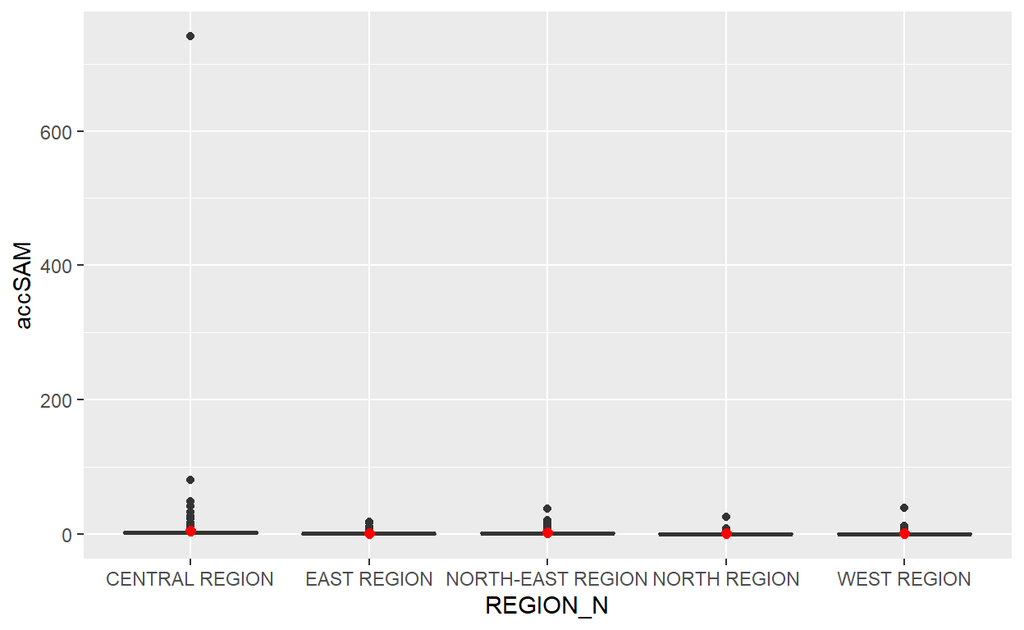

```r
ggplot(data=hexagon_SAM,
       aes(y = accSAM,
           x= REGION_N)) +
  geom_boxplot() +
  geom_point(stat="summary",
             fun.y="mean",
             colour ="red",
             size=2)
```